# 2. Timing Clonal Peaks

The `fit` function in the `tickTack` package estimates the timing of clonal peaks in cancer genome sequencing data. This vignette describes the functionality of the `fit` function, including input requirements, output, and an example analysis using the `tickTack::pcawg_example` dataset.

## Overview of the `fit` Function

The `fit` function uses either a beta-binomial or binomial model to fit clonal peaks in sequencing data. It identifies segments of the genome with specific karyotypes and mutations that meet the input criteria, then estimates the timing of clonal expansions.

### Key Parameters

- **`segments`**: A data frame with segment information, including `chr`, `from`, `to`, `Major`, and `minor`.
- **`mutations`**: A data frame with mutation data, including `chr`, `from`, `to`, `DP`, and `NV`.
- **`purity`**: Tumor purity as a numeric value.
- **`possible_k`**: A character vector of possible karyotypes, defaulting to `c("2:1", "2:2", "2:0")`.
- **`alpha`**: Significance level, defaulting to `0.05`.
- **`min_mutations_number`**: Minimum number of mutations required for analysis, defaulting to `2`.
- **`beta_binomial`**: Logical flag to use the beta-binomial model, default is `FALSE`.
- **`beta_binomial_disp`**: Dispersion parameter for the beta-binomial model, default is `0.01`.

### Output

The function returns a list containing:

1. **`inference_results`**: Detailed timing estimates for each segment.
2. **`summarized_results`**: Summary statistics for the estimated timing of clonal peaks.

If no segments meet the criteria, the function returns `NULL`.

## Analyzing `tickTack::pcawg_example`

We will use the `tickTack::pcawg_example` dataset to demonstrate how to use the `fit` function.

### Input Data

The `tickTack::pcawg_example` dataset contains three components:

- **`mutations`**: Mutation data.
- **`cna`**: Copy number alterations (CNA).
- **`metadata`**: Sample metadata, including tumor purity.

Preview the data:

```r
library(tickTack)

# View example dataset components
mutations <- tickTack::pcawg_example$mutations
cna <- tickTack::pcawg_example$cna
metadata <- tickTack::pcawg_example$metadata

head(mutations)
```

```
## # A tibble: 6 × 9
##   chr      from      to ref   alt      DP    NV   VAF sample
##   <chr>   <dbl>   <dbl> <chr> <chr> <dbl> <dbl> <dbl> <chr>
## 1 chr1  1015594 1015594 C     C        99    16 0.162 00db1b95-8ca3-4cc4-bb46-6…
## 2 chr1  1866371 1866371 C     C       250    67 0.268 00db1b95-8ca3-4cc4-bb46-6…
## 3 chr1  1921712 1921712 C     C        62    20 0.323 00db1b95-8ca3-4cc4-bb46-6…
## 4 chr1  2049858 2049858 G     G       118    15 0.127 00db1b95-8ca3-4cc4-bb46-6…
## 5 chr1  2357842 2357842 C     C        84    12 0.143 00db1b95-8ca3-4cc4-bb46-6…
## 6 chr1  2771915 2771915 G     G        90    27 0.3   00db1b95-8ca3-4cc4-bb46-6…
```

```r
head(cna)
```

```
## # A tibble: 6 × 7
##   chr       from        to Major minor   CCF total_cn
##   <chr>    <dbl>     <dbl> <dbl> <dbl> <dbl>    <dbl>
## 1 chr1     10001    790008     2     2 1            4
## 2 chr1    790009  13212499     2     2 1            4
## 3 chr1  13212500  33458785     2     2 1            4
## 4 chr1  33458786  33564126     2     2 0.194        4
## 5 chr1  33564127  56834601     2     2 1            4
## 6 chr1  56834602 121499999     2     2 1            4
```

```r
metadata
```

```
## # A tibble: 1 × 6
##   sample                  purity ploidy purity_conf_mad wgd_status wgd_uncertain
##   <chr>                    <dbl>  <dbl>           <dbl> <chr>      <lgl>
## 1 00db1b95-8ca3-4cc4-bb4…  0.406   4.08           0.009 wgd        FALSE
```

### Running the `fit` function

We can run the `fit` function on the `tickTack::pcawg_example` data to infer the timing of clonal peaks

[output not shown]

[output not shown]

[output cut: 295 more lines]

[output not shown]

[output not shown]

[output not shown]

[output cut: 295 more lines]

[output not shown]

[output not shown]

[output not shown]

[output cut: 295 more lines]

[output not shown]

[output not shown]

[output not shown]

[output cut: 295 more lines]

[output not shown]

[output not shown]

[output not shown]

[output cut: 295 more lines]

[output not shown]

[output not shown]

[output not shown]

[output cut: 295 more lines]

[output not shown]

[output not shown]

[output not shown]

[output cut: 295 more lines]

[output not shown]

[output not shown]

[output not shown]

[output cut: 295 more lines]

[output not shown]

[output not shown]

[output not shown]

[output cut: 295 more lines]

[output not shown]

[output not shown]

[output not shown]

[output cut: 295 more lines]

[output not shown]

[output not shown]

[output not shown]

[output cut: 295 more lines]

[output not shown]

[output not shown]

[output not shown]

[output cut: 295 more lines]

[output not shown]

[output not shown]

[output not shown]

[output cut: 295 more lines]

[output not shown]

[output not shown]

[output not shown]

[output cut: 295 more lines]

[output not shown]

[output not shown]

[output not shown]

[output cut: 295 more lines]

[output not shown]

[output not shown]

[output not shown]

[output cut: 295 more lines]

[output not shown]

[output not shown]

[output not shown]

[output cut: 295 more lines]

[output not shown]

[output not shown]

[output not shown]

[output cut: 295 more lines]

[output not shown]

[output not shown]

[output not shown]

[output cut: 295 more lines]

[output not shown]

[output not shown]

[output not shown]

[output cut: 295 more lines]

[output not shown]

[output not shown]

[output not shown]

[output cut: 295 more lines]

[output not shown]

[output not shown]

[output not shown]

[output cut: 295 more lines]

[output not shown]

[output not shown]

[output not shown]

[output cut: 295 more lines]

[output not shown]

[output not shown]

[output not shown]

[output cut: 295 more lines]

[output not shown]

[output not shown]

[output not shown]

[output cut: 295 more lines]

[output not shown]

[output not shown]

[output not shown]

[output cut: 295 more lines]

[output not shown]

[output not shown]

[output not shown]

[output cut: 295 more lines]

[output not shown]

[output not shown]

[output not shown]

[output cut: 295 more lines]

[output not shown]

[output not shown]

[output not shown]

[output cut: 295 more lines]

[output not shown]

[output not shown]

[output not shown]

[output cut: 295 more lines]

[output not shown]

[output not shown]

[output not shown]

[output cut: 295 more lines]

[output not shown]

[output not shown]

[output not shown]

[output cut: 295 more lines]

[output not shown]

[output not shown]

[output not shown]

[output cut: 295 more lines]

[output not shown]

[output not shown]

[output not shown]

[output cut: 295 more lines]

[output not shown]

[output not shown]

[output not shown]

[output cut: 295 more lines]

[output not shown]

[output not shown]

[output not shown]

[output cut: 295 more lines]

[output not shown]

[output not shown]

[output not shown]

[output cut: 295 more lines]

[output not shown]

[output not shown]

[output not shown]

[output cut: 295 more lines]

[output not shown]

[output not shown]

[output not shown]

[output cut: 295 more lines]

[output not shown]

[output not shown]

[output not shown]

[output cut: 295 more lines]

[output not shown]

[output not shown]

[output not shown]

[output cut: 295 more lines]

[output not shown]

[output not shown]

[output not shown]

[output cut: 295 more lines]

[output not shown]

[output not shown]

[output not shown]

[output cut: 295 more lines]

[output not shown]

[output not shown]

[output not shown]

[output cut: 295 more lines]

[output not shown]

[output not shown]

[output not shown]

[output cut: 295 more lines]

[output not shown]

[output not shown]

[output not shown]

[output cut: 295 more lines]

[output not shown]

[output not shown]

[output not shown]

[output cut: 295 more lines]

[output not shown]

[output not shown]

[output not shown]

[output cut: 295 more lines]

[output not shown]

[output not shown]

[output not shown]

[output cut: 295 more lines]

[output not shown]

[output not shown]

[output not shown]

[output cut: 295 more lines]

[output not shown]

[output not shown]

[output not shown]

[output cut: 295 more lines]

[output not shown]

[output not shown]

[output not shown]

[output cut: 295 more lines]

[output not shown]

[output not shown]

[output not shown]

[output cut: 295 more lines]

[output not shown]

[output not shown]

[output not shown]

[output cut: 295 more lines]

[output not shown]

[output not shown]

[output not shown]

[output cut: 295 more lines]

[output not shown]

[output not shown]

[output not shown]

[output cut: 295 more lines]

[output not shown]

[output not shown]

[output not shown]

[output cut: 295 more lines]

[output not shown]

[output not shown]

[output not shown]

[output cut: 295 more lines]

[output not shown]

[output not shown]

[output not shown]

[output cut: 295 more lines]

[output not shown]

[output not shown]

[output not shown]

[output cut: 295 more lines]

[output not shown]

[output not shown]

[output not shown]

[output cut: 295 more lines]

[output not shown]

[output not shown]

[output not shown]

[output cut: 295 more lines]

[output not shown]

[output not shown]

[output not shown]

[output cut: 295 more lines]

[output not shown]

[output not shown]

[output not shown]

[output cut: 295 more lines]

[output not shown]

[output not shown]

[output not shown]

[output cut: 295 more lines]

[output not shown]

[output not shown]

[output not shown]

[output cut: 295 more lines]

[output not shown]

[output not shown]

[output not shown]

[output cut: 295 more lines]

[output not shown]

[output not shown]

[output not shown]

[output cut: 295 more lines]

[output not shown]

[output not shown]

[output not shown]

[output cut: 295 more lines]

[output not shown]

[output not shown]

[output not shown]

[output cut: 295 more lines]

[output not shown]

[output not shown]

[output not shown]

[output cut: 295 more lines]

[output not shown]

[output not shown]

[output not shown]

[output cut: 295 more lines]

[output not shown]

### Results

The `results` object contains two components: `inference_results` and `summarized_results`. We can inspect these to understand the timing of clonal peaks:

```r
# View summarized results
results$summarized_results
```

```
## # A tibble: 72 × 7
##    tau_low tau_mean tau_high segment karyotype chr   segment_id
##      <dbl>    <dbl>    <dbl>   <int> <chr>     <chr> <chr>
##  1   0.807    0.890    0.953       2 2:2       chr1  chr1_790009_13212499
##  2   0.843    0.911    0.963       3 2:2       chr1  chr1_13212500_33458785
##  3   0.816    0.889    0.944       5 2:2       chr1  chr1_33564127_56834601
##  4   0.863    0.903    0.936       6 2:2       chr1  chr1_56834602_121499999
##  5   0.395    0.683    0.890      10 2:2       chr1  chr1_143277461_149255831
##  6   0.806    0.866    0.914      11 2:2       chr1  chr1_149255832_196892499
##  7   0.808    0.862    0.909      12 2:2       chr1  chr1_196892500_247247500
##  8   0.543    0.790    0.947      13 2:2       chr1  chr1_247247501_249250620
##  9   0.769    0.825    0.875      30 2:2       chr4  chr4_74473_48199999
## 10   0.459    0.766    0.953      31 2:2       chr4  chr4_48200000_52699999
## # ℹ 62 more rows
```

```r
# View detailed inference results
results$inference_results
```

```
## # A tibble: 1,152,000 × 5
##      tau segment karyotype chr   segment_id
##    <dbl>   <int> <chr>     <chr> <chr>
##  1 0.853       2 2:2       chr1  chr1_790009_13212499
##  2 0.873       2 2:2       chr1  chr1_790009_13212499
##  3 0.869       2 2:2       chr1  chr1_790009_13212499
##  4 0.912       2 2:2       chr1  chr1_790009_13212499
##  5 0.891       2 2:2       chr1  chr1_790009_13212499
##  6 0.889       2 2:2       chr1  chr1_790009_13212499
##  7 0.889       2 2:2       chr1  chr1_790009_13212499
##  8 0.922       2 2:2       chr1  chr1_790009_13212499
##  9 0.935       2 2:2       chr1  chr1_790009_13212499
## 10 0.912       2 2:2       chr1  chr1_790009_13212499
## # ℹ 1,151,990 more rows
```

### Interpreting the output

- **`inference_results`**: Contains posterior distributions of timing estimates (`tau`) for each segment.
- **`summarized_results`**: Provides the mean, lower bound, and upper bound of the timing estimates for each segment.

## Visulizing the output

The results can be viewed is genome-wise perspective using the `tickTack::plot_timing` function

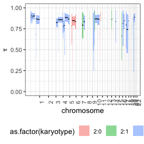

```r
tickTack::plot_timing(results, segments, colour_by = "karyotype")
```